# Medicare data challenge

## 4.4 interpretation of the model

```r
summary(fit2)
```

```
## Linear mixed model fit by REML ['lmerMod']
## Formula: rating ~ flu_shot + operation + hospital + HHA + (1 | state)
##    Data: hca
##
## REML criterion at convergence: 8113.4
##
## Scaled residuals:
##     Min      1Q  Median      3Q     Max
## -3.3337 -0.6821 -0.0182  0.6711  4.1295
##
## Random effects:
##  Groups   Name        Variance Std.Dev.
##  state    (Intercept) 0.09882  0.3144
##  Residual             0.37787  0.6147
## Number of obs: 4257, groups:  state, 53
##
## Fixed effects:
##               Estimate Std. Error t value
## (Intercept)  0.2098748  0.1580791    1.33
## flu_shot     0.0313417  0.0008548   36.66
## operation    0.0193210  0.0013092   14.76
## hospital    -0.0418862  0.0032093  -13.05
## HHA         -0.2083542  0.0603859   -3.45
##
## Correlation of Fixed Effects:
##           (Intr) fl_sht opertn hosptl
## flu_shot  -0.316
## operation -0.697 -0.146
## hospital  -0.342  0.018  0.000
## HHA       -0.389  0.014  0.018 -0.012
```

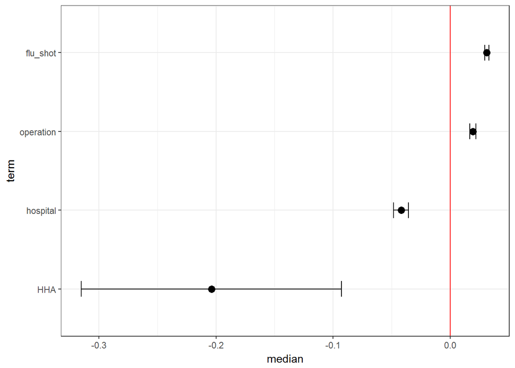

```r
library(merTools)
plotFEsim(FEsim(fit2))
```

From this plot, we could see that the HHA which mean whether the agency offers home health aid or not have negative effect on star rating. And hospital which means how often home health patients who have had a recent hospital stay had to be readmitted to the hospital has a negaive effect on the star rating. While flu shot and operation which means how often the home health team determined whether patients received a flu shot for the curent flu season and how often patients wounds improved or healed after an operation have an positive effect on the star rating.

# 5. Further discussion

For my home health care agency exploration, I fit several multilevel models and find the best model fit. However, I only use some certain variables as factors, but there are many other variables in the dataset that can be used to determine the influence on star rating of each agency. Futhermore, there might be some correlation between the variables in the models that I fit. So for my future direction, I will be focusing on some other variables and the correlation beween the variables.